# Algoritmos

2026-04-01

## Primeros comandos de R

R es un lenguaje muy similar a Matlab y permite el trabajo con matrices.

```
## [1] 20
```

## Uso de data sets o base de datos internos de R

Usando el comando data en la consola obtenemos distintos datos ya cargados en la base de datos de R, estos datos estan dados en tablas de las cuales podemos elegir columnas especificas si escribimos $ despues de el comando de informacion especifico y elegimos la columna de datos deseada

```
##      speed           dist
##  Min.   : 4.0   Min.   :  2.00
##  1st Qu.:12.0   1st Qu.: 26.00
##  Median :15.0   Median : 36.00
##  Mean   :15.4   Mean   : 42.98
##  3rd Qu.:19.0   3rd Qu.: 56.00
##  Max.   :25.0   Max.   :120.00
```

## Comando Plot

Es un comando que permite graficar cualquier fuente de datos que le asignemos ,teniendo también la posibilidad de asignar nombre a las variables o hacer cambios al gráfico.En caso de duda de como utilizar el comando podemos escribir **?plot** en la consola,lo cual abrirá una ventana que explicara en detalle el comando.

## funciones estadisticas

```
##   [1] 22.074179 14.344162 23.551786 15.045863 19.138394 27.591327 27.044006
##   [8] 23.462451 32.504557 22.706285 25.163902 18.647339 19.443534 23.942937
##  [15] 29.164496 20.779747 21.484570 24.657204 23.729611 19.726326 21.560340
##  [22] 29.243518 21.091110 22.820435 24.638867 22.658905 26.787762 28.144476
##  [29] 30.886003 21.943565 21.350284 17.722077 18.253423 24.270221 21.277580
##  [36] 27.564312 21.002663 20.872775 30.572522 17.474475 24.824833 22.684346
##  [43] 17.544922 17.580051 25.840130 23.024720 18.252650 22.806643 24.800717
##  [50] 35.185939 21.031692 17.830837 24.151046 24.306065 18.539372 19.671684
##  [57] 13.808162 15.463851 14.442307 17.214937 17.636533 22.054765 26.819923
##  [64] 26.495813 28.036295 19.340992 11.572352 18.393775 26.954796 18.965525
##  [71] 15.302810 16.940668 21.695190 15.555851 26.027812 19.202303 21.689816
##  [78] 22.315558 23.081603 24.616042 17.130053 24.354724 19.774086 24.984025
##  [85] 18.912037 22.004376 24.637975 25.045224 25.715960 31.230030 23.746931
##  [92] 24.945536 17.884616 27.253875 23.999330 20.690183 22.135977 21.671378
##  [99] 20.140980 24.160543 18.682639 26.795375 26.319003 17.136605 23.775999
```

[output cut: 35 more lines]

```
## [1] 350
```

```
##   [1] 500 501 502 503 504 505 506 507 508 509 510 511 512 513 514 515 516 517
##  [19] 518 519 520 521 522 523 524 525 526 527 528 529 530 531 532 533 534 535
##  [37] 536 537 538 539 540 541 542 543 544 545 546 547 548 549 550 551 552 553
##  [55] 554 555 556 557 558 559 560 561 562 563 564 565 566 567 568 569 570 571
##  [73] 572 573 574 575 576 577 578 579 580 581 582 583 584 585 586 587 588 589
##  [91] 590 591 592 593 594 595 596 597 598 599 600 601 602 603 604 605 606 607
## [109] 608 609 610 611 612 613 614 615 616 617 618 619 620 621 622 623 624 625
## [127] 626 627 628 629 630 631 632 633 634 635 636 637 638 639 640 641 642 643
## [145] 644 645 646 647 648 649 650 651 652 653 654 655 656 657 658 659 660 661
## [163] 662 663 664 665 666 667 668 669 670 671 672 673 674 675 676 677 678 679
## [181] 680 681 682 683 684 685 686 687 688 689 690 691 692 693 694 695 696 697
## [199] 698 699 700 701 702 703 704 705 706 707 708 709 710 711 712 713 714 715
## [217] 716 717 718 719 720 721 722 723 724 725 726 727 728 729 730 731 732 733
## [235] 734 735 736 737 738 739 740 741 742 743 744 745 746 747 748 749 750 751
## [253] 752 753 754 755 756 757 758 759 760 761 762 763 764 765 766 767 768 769
## [271] 770 771 772 773 774 775 776 777 778 779 780 781 782 783 784 785 786 787
## [289] 788 789 790 791 792 793 794 795 796 797 798 799 800 801 802 803 804 805
## [307] 806 807 808 809 810 811 812 813 814 815 816 817 818 819 820 821 822 823
## [325] 824 825 826 827 828 829 830 831 832 833 834 835 836 837 838 839 840 841
## [343] 842 843 844 845 846 847 848 849
```

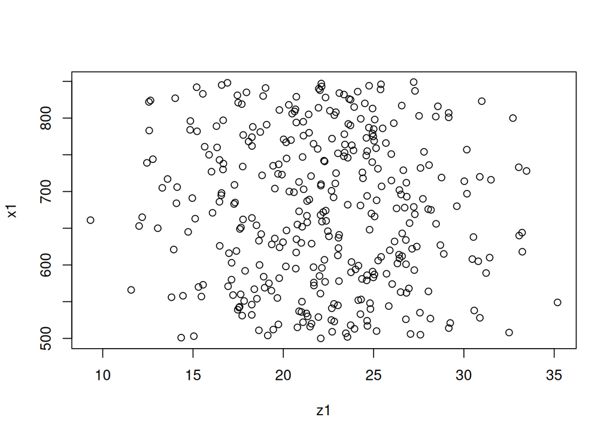

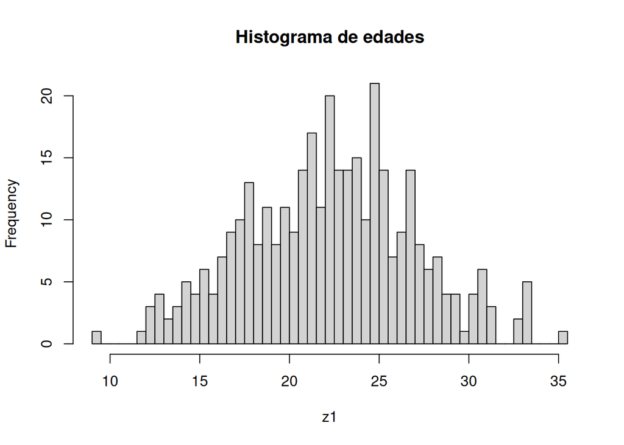

```
##
## Call:
##  density.default(x = z1)
##
## Data: z1 (350 obs.); Bandwidth 'bw' = 1.309
##
##        x                y
##  Min.   : 5.393   Min.   :9.733e-06
##  1st Qu.:13.823   1st Qu.:2.373e-03
##  Median :22.254   Median :1.878e-02
##  Mean   :22.254   Mean   :2.960e-02
##  3rd Qu.:30.684   3rd Qu.:5.615e-02
##  Max.   :39.114   Max.   :8.297e-02
```

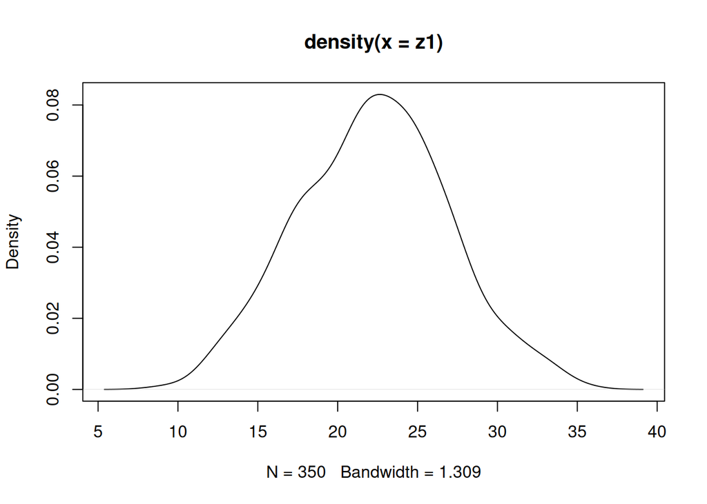

## Ejercicio 1 de algoritmos

consigna: Los ultimos 3 cifras de mi DNI 007, consigna crear una variable que tenga ese numero

Consigna: Crear un vector que tenga todos los numeros hasta el 007 enteros

```
## [1] 1 2 3 4 5 6 7
```

## Ejercicio 2:

```
## [1] "2026-04-22 21:25:38 UTC"
```

```
## [1] 61250175000
```

```
## [1] "2026-04-22 21:25:38 UTC"
```

## Ejercicio 3

Repetir el ejercicio anterior pero en python

```
## 28
```

## Ejercicio 4

Hacer lo mismo en Julia

Dicho ejercicio no se puede hacer por la compatibilidad de Julia con posit cloud.

## Ejercicio 5

```
## [1] "2026-04-22 21:25:39 UTC"
```

```
## [1] 61250175000
```

```
## [1] "2026-04-22 21:25:39 UTC"
```

## Ejerjecio 6

```
## [1] "2026-04-22 21:25:39 UTC"
```

```
## [1] 61250175000
```

```
## [1] "2026-04-22 21:25:39 UTC"
```

## Ejercicio 7

```
##  [1]  0  1  1  2  3  5  8 13 21 34
```

```
## El primer número mayor a 1,000,000 es: 1346269
```

```
## Se necesitaron 30 iteraciones.
```

```
## Tiempo con fibonacci_recursivo: 0.005356073 segundos
```

```
## Tiempo con fibonacci_iterativo: 0.004554749 segundos
```

## Ejercicio 8

Compara la performance de ordenación del método burbuja vs el método sort de R Mustra

```
##     [1] 51663 57870  2986 29925 95246 68293 62555 45404 65161 46435  9642 59134
##    [13] 52132 96849 14183 15180 27168 89709  9097 30538 56219 94517  7989 13536
##    [25] 90077  6216 83519 29394 53241 28825    41 14426 72820 51656 94038 58527
##    [37] 77009 43042 77837  6134 33523 21812 39895  9640 85278  9326 26510 20960
##    [49] 14403 64502 71503 45221 94335 92372 77585 80686 70563 32606 16152 25559
##    [61] 14215 14287 23194 90094 34976 14491 82949 77584 40503 34724 86013 17369
##    [73] 31542 59106 86605 40632 96111 43204 37544 99289 84427 76820 82115 44196
##    [85] 92337 44983 91438 36717 28078 69369 91564 43406 41488 47485 63528 14536
##    [97] 83069 51465 26503 88299 32953   413 10762 48182 30571 42521 74522 14745
##   [109] 25946 80340 43928  6601 57701 53518 72326 52353 66154 47802 31517 66075
##   [121] 32263 95989 69161 81118 56157 19392 46137 67747  2286 59970 84298 54661
##   [133] 32281 64085  7826 80287 89799 25449 63405 76223 64616 27455 54740 78173
##   [145] 20193 66701 97201 22467 95362 63167 79225 63658 49862 84032 79331 84955
##   [157] 51491 15703  6623  8983 37769 29479 70943 98170 78121 86621  1835 42221
##   [169] 21099 41043 90978 56529 36940 97455 76099 38265 76384 46438 75176 88461
```

[output cut: 1652 more lines]

Metodo de burbuja

```
##     [1]     5     7     8    10    18    21    30    31    32    38    41    43
##    [13]    47    53    55    56    57    60    76    85    95    98   100   112
##    [25]   114   119   126   127   134   137   147   153   156   163   165   167
##    [37]   175   180   184   188   191   205   206   210   211   215   225   228
##    [49]   237   242   250   254   257   260   276   279   280   281   290   303
##    [61]   304   305   306   317   321   323   324   326   335   339   342   352
##    [73]   353   354   360   379   386   388   391   396   397   407   413   424
##    [85]   430   432   438   444   451   470   474   475   481   486   488   526
##    [97]   528   529   532   534   535   543   550   557   563   586   599   602
##   [109]   604   608   609   611   615   620   622   625   627   630   632   637
##   [121]   638   639   640   649   652   663   670   674   698   705   706   710
##   [133]   716   718   724   725   742   743   747   756   765   766   772   784
##   [145]   786   787   791   792   802   805   823   837   839   845   851   852
##   [157]   855   858   883   887   893   894   899   905   907   914   916   923
##   [169]   925   927   933   941   947   948   952   954   970   971   974   975
```

[output cut: 1652 more lines]

Metodo con sort de R

```
##     [1]     5     7     8    10    18    21    30    31    32    38    41    43
##    [13]    47    53    55    56    57    60    76    85    95    98   100   112
##    [25]   114   119   126   127   134   137   147   153   156   163   165   167
##    [37]   175   180   184   188   191   205   206   210   211   215   225   228
##    [49]   237   242   250   254   257   260   276   279   280   281   290   303
##    [61]   304   305   306   317   321   323   324   326   335   339   342   352
##    [73]   353   354   360   379   386   388   391   396   397   407   413   424
##    [85]   430   432   438   444   451   470   474   475   481   486   488   526
##    [97]   528   529   532   534   535   543   550   557   563   586   599   602
##   [109]   604   608   609   611   615   620   622   625   627   630   632   637
##   [121]   638   639   640   649   652   663   670   674   698   705   706   710
##   [133]   716   718   724   725   742   743   747   756   765   766   772   784
##   [145]   786   787   791   792   802   805   823   837   839   845   851   852
##   [157]   855   858   883   887   893   894   899   905   907   914   916   923
##   [169]   925   927   933   941   947   948   952   954   970   971   974   975
```

[output cut: 1652 more lines]

```
## Unit: microseconds
##     expr         min          lq         mean       median          uq
##  burbuja 2.06964e+07 21172435.65 2.138162e+07 21236277.116 21885777.70
##   sort_r 6.24811e+02      657.65 7.048924e+02      726.171      750.62
##          max neval
##  21917227.48     5
##       765.21     5
```

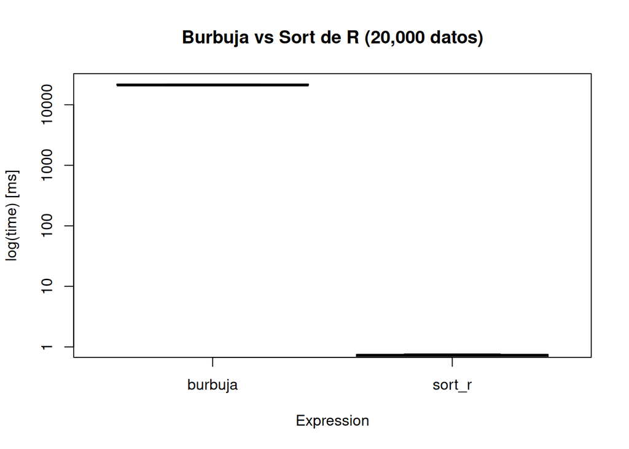

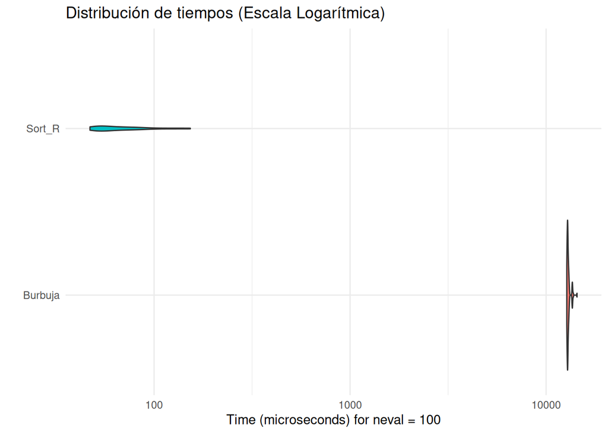

## Ejercicio 9

La penitencia de Newton

Consigna de trabajo : Desarrolla dos algoritmos que hagan el resultado de la suma de desde el número 1 hasta cierto número aleatoriamente elegido , por ejemplo para sumar desde 1 hasta 1 * 1010 y verifica cuál de los dos es más eficiente.

```
## [1] 7.605002e+12
```

```
## [1] 7.605002e+12
```

```
## Suma total: 7.605002e+12
```

```
## Tiempo con bucle for: 0.06625199 segundos
```

```
## Tiempo con método Gauss: 0.001734018 segundos
```

## Ejercicio 10

Cohesión ($a_i$): Distancia promedio entre el punto $i$ y todos los demás puntos de su mismo clúster.Separación ($b_i$): Distancia promedio entre el punto $i$ y los puntos del clúster más cercano.

Aplicacion del metodo K-means

```
## Welcome to factoextra!
```

```
## Want to learn more? See two factoextra-related books at https://www.datanovia.com/en/product/practical-guide-to-principal-component-methods-in-r/
```

```
## Calculando el número óptimo de clústeres por consenso...
```

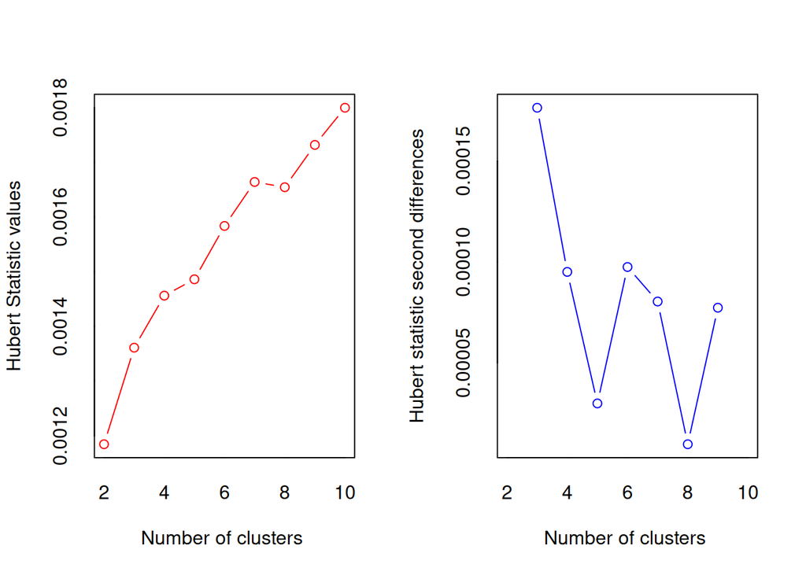

```
## *** : The Hubert index is a graphical method of determining the number of clusters.
##                 In the plot of Hubert index, we seek a significant knee that corresponds to a
##                 significant increase of the value of the measure i.e the significant peak in Hubert
##                 index second differences plot.
##
```

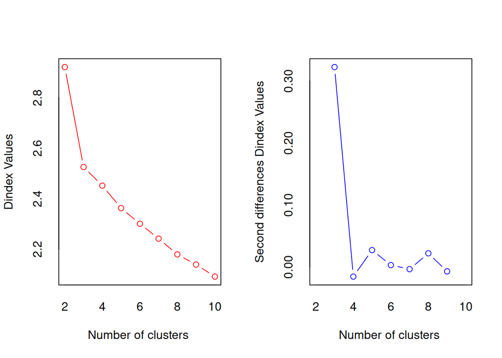

```
## *** : The D index is a graphical method of determining the number of clusters.
##                 In the plot of D index, we seek a significant knee (the significant peak in Dindex
##                 second differences plot) that corresponds to a significant increase of the value of
##                 the measure.
##
## * Among all indices:
## * 2 proposed 2 as the best number of clusters
## * 19 proposed 3 as the best number of clusters
## * 2 proposed 10 as the best number of clusters
##
##                    ***** Conclusion *****
##
## * According to the majority rule, the best number of clusters is  3
##
##
```

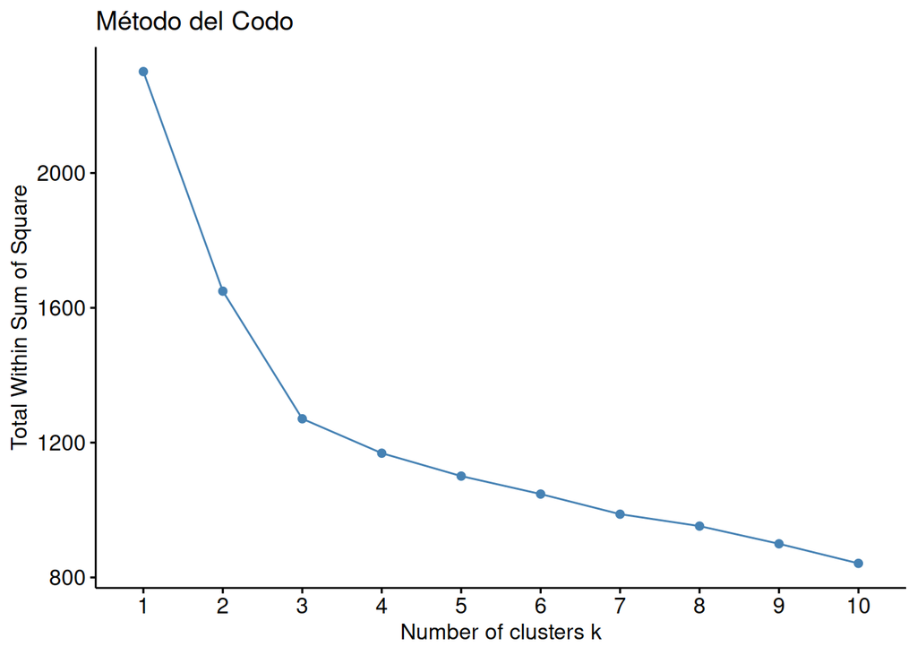

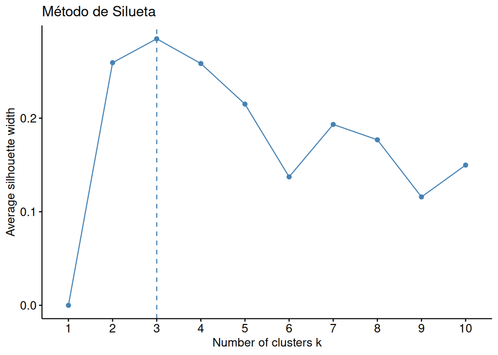

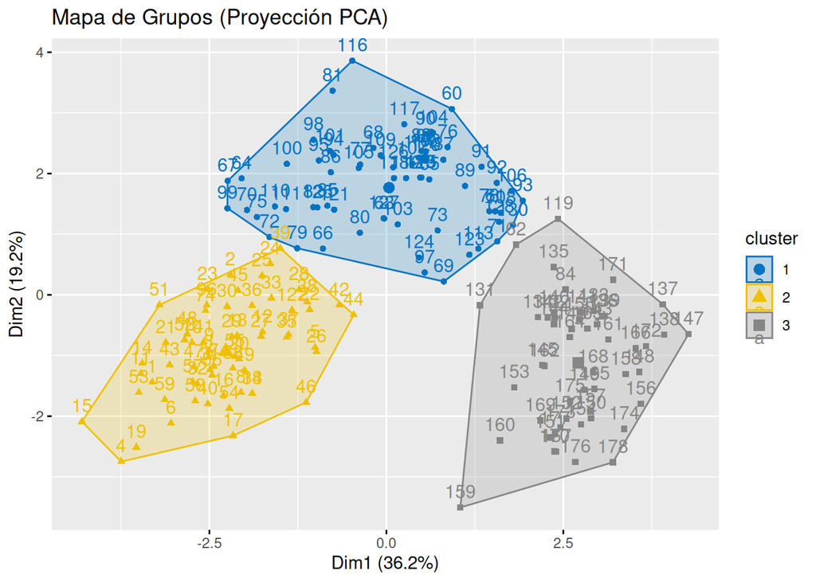

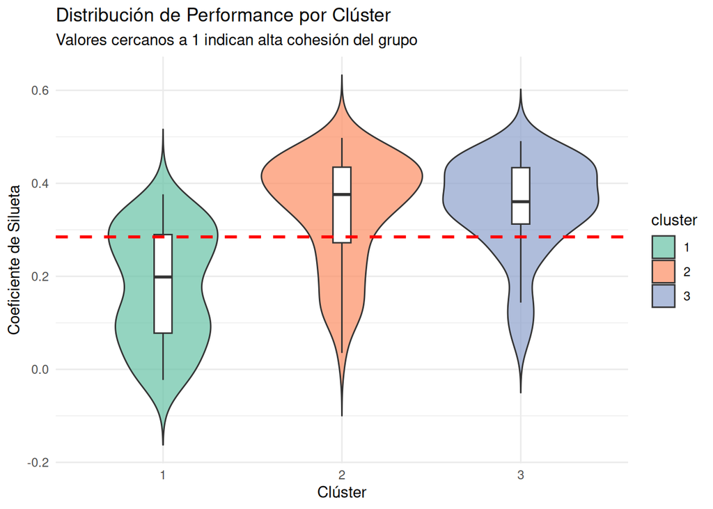

```
## El promedio global de silueta es: 0.2848589
```